```python
from IPython.display import Image
```

# **Variables categoricas**

Muchos algoritmos de aprendizaje automático no pueden manejar las variables categóricas por sí mismas a menos que las convirtamos en valores numéricos. Los resultados producidos por el modelo varían según las diferentes técnicas de codificación utilizadas.

Las variables categóricas pueden dividirse en dos categorías:

1. Nominal (Sin orden particular)
2. Ordinal (con algún orden)

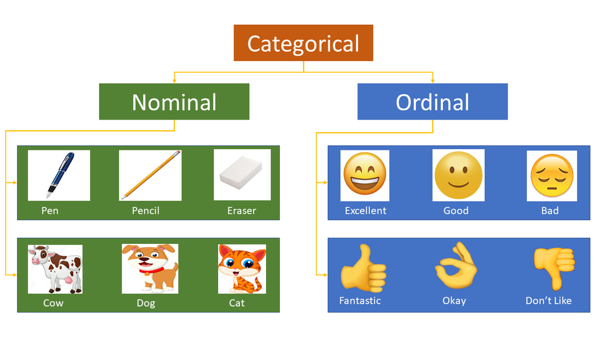

```python
Image("Screenshots/Categorical_variables.png")
```

En la librería category_encoders y en sklearn hay muchas formas de codificar las variables categoricas: https://contrib.scikit-learn.org/category_encoders/

1. One Hot Encoding
2. Label Encoding
3. Ordinal Encoding
4. Frequency or Count Encoding
5. Binary Encoding
6. Base-N Encoding
7. Helmert Encoding
8. Mean Encoding or Target Encoding
9. Weight of Evidence Encoding
10. Sum Encoder (Deviation Encoding or Effect Encoding)
11. Leave One Out Encoding
12. CatBoost Encoding
13. James-Stein Encoding
14. M-estimator Encoding
15. Hashing Encoding
16. Backward Difference Encoding
17. Polynomial Encoding
18. MultiLabelBinarizer

## Importo librerías

```python
import pandas as pd
import numpy as np
import sklearn
import category_encoders as ce
from sklearn.preprocessing import OneHotEncoder
from sklearn.preprocessing import OrdinalEncoder
```

# Ejemplos

```python
data = {'Temperature':['Hot','Cold','Very Hot','Warm','Hot','Warm','Warm','Hot','Hot','Cold'],
        'Color':['Red','Yellow','Blue','Blue','Red','Yellow','Red','Yellow','Yellow','Yellow'],
        'Target':[1,1,1,0,1,0,1,0,1,1]}
df = pd.DataFrame(data)
df
```

|  | Temperature | Color | Target |
| --- | --- | --- | --- |
| 0 | Hot | Red | 1 |
| 1 | Cold | Yellow | 1 |
| 2 | Very Hot | Blue | 1 |
| 3 | Warm | Blue | 0 |
| 4 | Hot | Red | 1 |
| 5 | Warm | Yellow | 0 |
| 6 | Warm | Red | 1 |
| 7 | Hot | Yellow | 0 |
| 8 | Hot | Yellow | 1 |
| 9 | Cold | Yellow | 1 |

## 1. One Hot Encoding

En esta técnica, se crea una nueva columna para cada categoría de la variable categórica y se sustituye por 1 (presencia de la característica) o 0 (ausencia de la característica). Si el número de categorías es muy elevado, dificulta el aprendizaje de los modelos debido a la alta dimensionalidad

```python
ohe = OneHotEncoder()
oh_array = ohe.fit_transform(df['Temperature'].values.reshape(-1, 1)).toarray()
oh_df = pd.DataFrame(oh_array,columns=['Temp_Cold','Temp_Hot','Temp_Very_Hot','Temp_Warm'])
pd.concat([df,oh_df],axis=1)
```

|  | Temperature | Color | Target | Temp_Cold | Temp_Hot | Temp_Very_Hot | Temp_Warm |
| --- | --- | --- | --- | --- | --- | --- | --- |
| 0 | Hot | Red | 1 | 0.0 | 1.0 | 0.0 | 0.0 |
| 1 | Cold | Yellow | 1 | 1.0 | 0.0 | 0.0 | 0.0 |
| 2 | Very Hot | Blue | 1 | 0.0 | 0.0 | 1.0 | 0.0 |
| 3 | Warm | Blue | 0 | 0.0 | 0.0 | 0.0 | 1.0 |
| 4 | Hot | Red | 1 | 0.0 | 1.0 | 0.0 | 0.0 |
| 5 | Warm | Yellow | 0 | 0.0 | 0.0 | 0.0 | 1.0 |
| 6 | Warm | Red | 1 | 0.0 | 0.0 | 0.0 | 1.0 |
| 7 | Hot | Yellow | 0 | 0.0 | 1.0 | 0.0 | 0.0 |
| 8 | Hot | Yellow | 1 | 0.0 | 1.0 | 0.0 | 0.0 |
| 9 | Cold | Yellow | 1 | 1.0 | 0.0 | 0.0 | 0.0 |

```python
ohe = ce.OneHotEncoder(cols=['Temperature'])
ce_ohe = ohe.fit_transform(df.iloc[:,0], df.iloc[:,-1])
ce_ohe.columns = ['Temp_Hot','Temp_Cold','Temp_Very_Hot','Temp_Warm']
pd.concat([df,ce_ohe],axis=1)
```

|  | Temperature | Color | Target | Temp_Hot | Temp_Cold | Temp_Very_Hot | Temp_Warm |
| --- | --- | --- | --- | --- | --- | --- | --- |
| 0 | Hot | Red | 1 | 1 | 0 | 0 | 0 |
| 1 | Cold | Yellow | 1 | 0 | 1 | 0 | 0 |
| 2 | Very Hot | Blue | 1 | 0 | 0 | 1 | 0 |
| 3 | Warm | Blue | 0 | 0 | 0 | 0 | 1 |
| 4 | Hot | Red | 1 | 1 | 0 | 0 | 0 |
| 5 | Warm | Yellow | 0 | 0 | 0 | 0 | 1 |
| 6 | Warm | Red | 1 | 0 | 0 | 0 | 1 |
| 7 | Hot | Yellow | 0 | 1 | 0 | 0 | 0 |
| 8 | Hot | Yellow | 1 | 1 | 0 | 0 | 0 |
| 9 | Cold | Yellow | 1 | 0 | 1 | 0 | 0 |

1. Para la regresión, podemos utilizar N-1 (eliminando una columna, sino habría colinealidad),
2. Para la clasificación basado en ensemblig de árboles se pueden usar las n columnas.

**Desventajas:** Cuando la variable contiene demasiados valores únicos, se crean muchas nuevas variables que pueden dar lugar a sobreajuste.

## 2. Ordinal Encoding

```python
oe = OrdinalEncoder()
oe_val = oe.fit_transform(df['Temperature'].values.reshape(-1, 1))
pd.concat([df,pd.DataFrame(oe_val,columns=['Temperature_Oe'])],axis=1)
```

|  | Temperature | Color | Target | Temperature_Oe |
| --- | --- | --- | --- | --- |
| 0 | Hot | Red | 1 | 1.0 |
| 1 | Cold | Yellow | 1 | 0.0 |
| 2 | Very Hot | Blue | 1 | 2.0 |
| 3 | Warm | Blue | 0 | 3.0 |
| 4 | Hot | Red | 1 | 1.0 |
| 5 | Warm | Yellow | 0 | 3.0 |
| 6 | Warm | Red | 1 | 3.0 |
| 7 | Hot | Yellow | 0 | 1.0 |
| 8 | Hot | Yellow | 1 | 1.0 |
| 9 | Cold | Yellow | 1 | 0.0 |

```python
ohe = ce.OrdinalEncoder(cols=['Temperature'])
df['Temp_ce_oe'] = ohe.fit_transform(df.iloc[:,0], df.iloc[:,-1])
df
```

|  | Temperature | Color | Target | Temp_ce_oe |
| --- | --- | --- | --- | --- |
| 0 | Hot | Red | 1 | 1 |
| 1 | Cold | Yellow | 1 | 2 |
| 2 | Very Hot | Blue | 1 | 3 |
| 3 | Warm | Blue | 0 | 4 |
| 4 | Hot | Red | 1 | 1 |
| 5 | Warm | Yellow | 0 | 4 |
| 6 | Warm | Red | 1 | 4 |
| 7 | Hot | Yellow | 0 | 1 |
| 8 | Hot | Yellow | 1 | 1 |
| 9 | Cold | Yellow | 1 | 2 |

## 3. Frequency or Count Encoder

En la codificación por frecuencia, cada una de las categorías de la variable se sustituye por las frecuencias de las categorías.

[figure not shown]

```python
ce = ce.CountEncoder(cols=['Temperature'])
df['Temp_Count_Enc'] = ce.fit_transform(df.iloc[:,0], df.iloc[:,-1])
df
```

|  | Temperature | Color | Target | Temp_Count_Enc |
| --- | --- | --- | --- | --- |
| 0 | Hot | Red | 1 | 4 |
| 1 | Cold | Yellow | 1 | 2 |
| 2 | Very Hot | Blue | 1 | 1 |
| 3 | Warm | Blue | 0 | 3 |
| 4 | Hot | Red | 1 | 4 |
| 5 | Warm | Yellow | 0 | 3 |
| 6 | Warm | Red | 1 | 3 |
| 7 | Hot | Yellow | 0 | 4 |
| 8 | Hot | Yellow | 1 | 4 |
| 9 | Cold | Yellow | 1 | 2 |

**Cuidado!**: Si dos categorías tienen la misma frecuencia, entonces su codificación es la misma y no se distinguen

## 4. Mean Encoding or Target Encoding

Es el método más empleado con variables que tienen un elevado número de categorías

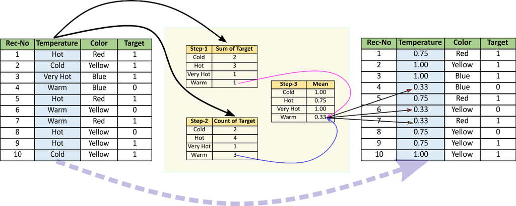

```python
Image("Screenshots/Mean_Encoding.png")
```

```python
te = ce.TargetEncoder(cols=['Temperature'])
df['Temperature_ce_TarEnc'] = te.fit_transform(df['Temperature'],df.Target)
df
```

|  | Temperature | Color | Target | Temperature_ce_TarEnc |
| --- | --- | --- | --- | --- |
| 0 | Hot | Red | 1 | 0.747629 |
| 1 | Cold | Yellow | 1 | 0.919318 |
| 2 | Very Hot | Blue | 1 | 0.700000 |
| 3 | Warm | Blue | 0 | 0.377041 |
| 4 | Hot | Red | 1 | 0.747629 |
| 5 | Warm | Yellow | 0 | 0.377041 |
| 6 | Warm | Red | 1 | 0.377041 |
| 7 | Hot | Yellow | 0 | 0.747629 |
| 8 | Hot | Yellow | 1 | 0.747629 |
| 9 | Cold | Yellow | 1 | 0.919318 |

**Desventaja:** Al usar información de la variable objetivo, hay que tener cuidado de no sobreajustar los modelos. Se pueden introducir parámetros que evitan el sobreajuste

## 5. Weight of Evidence Encoding

1. Este método se emplear si la variable objetivo es binaria, por ejemplo para medir riesgos de impago.
2. Mide la distinción de cada categoría de la variable del riesgo de impago.

[figure not shown]

   Distr Goods -> Distribucion de préstamos devueltos (por ejemplo)  
   Distr bads -> Distribución de préstamos no devueltos

```python
woe = ce.WOEEncoder(cols=['Temperature'])
df['Temperature_ce_WOE'] = woe.fit_transform(df['Temperature'],df.Target)
df
```

|  | Temperature | Color | Target | Temperature_ce_WOE |
| --- | --- | --- | --- | --- |
| 0 | Hot | Red | 1 | 0.105361 |
| 1 | Cold | Yellow | 1 | 0.510826 |
| 2 | Very Hot | Blue | 1 | 0.000000 |
| 3 | Warm | Blue | 0 | -0.993252 |
| 4 | Hot | Red | 1 | 0.105361 |
| 5 | Warm | Yellow | 0 | -0.993252 |
| 6 | Warm | Red | 1 | -0.993252 |
| 7 | Hot | Yellow | 0 | 0.105361 |
| 8 | Hot | Yellow | 1 | 0.105361 |
| 9 | Cold | Yellow | 1 | 0.510826 |

## 6. CatBoost Encoder

Es similar al target encoding. Pero, para evitar el sobreajuste, el proceso de codificación de categorías para el conjunto de datos de entrenamiento se repite varias veces en versiones barajadas del conjunto de datos y los resultados se promedian.

```python
cbe = ce.CatBoostEncoder(cols=['Temperature'])
df['Temperature_ce_CBE'] = cbe.fit_transform(df['Temperature'],df.Target)
df
```

|  | Temperature | Color | Target | Temperature_ce_CBE |
| --- | --- | --- | --- | --- |
| 0 | Hot | Red | 1 | 0.700000 |
| 1 | Cold | Yellow | 1 | 0.700000 |
| 2 | Very Hot | Blue | 1 | 0.700000 |
| 3 | Warm | Blue | 0 | 0.700000 |
| 4 | Hot | Red | 1 | 0.850000 |
| 5 | Warm | Yellow | 0 | 0.350000 |
| 6 | Warm | Red | 1 | 0.233333 |
| 7 | Hot | Yellow | 0 | 0.900000 |
| 8 | Hot | Yellow | 1 | 0.675000 |
| 9 | Cold | Yellow | 1 | 0.850000 |